# index

## NaNoGenMo 2020 with P.G. Wodehouse

- Summary
- Apologia
- Technical Details
- Conclusion
- Sources

### Summary

Train a TensorFlow model on P.G. Wodehouse, produce [some novels](https://github.com/risatrix/NaNoGenMo2020/tree/main/novels), then name them with NLP and make [bad cover art](https://github.com/risatrix/NaNoGenMo2020/tree/main/covers) like so:

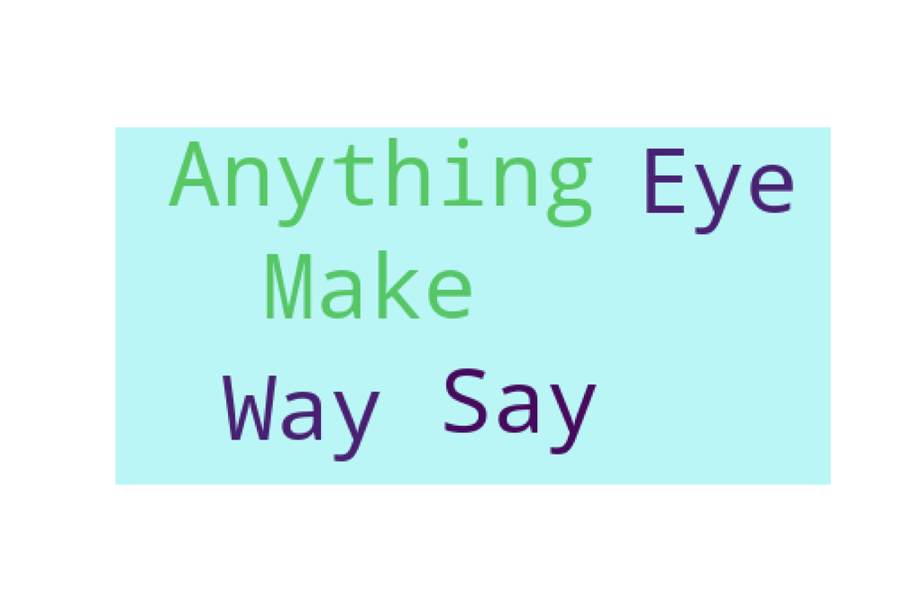

### Why this is a terrible idea, but I did it anyway

I'd been meaning to participate NaNoGenMo for a some time, and I certainly didn't expect that 2020 would be the year I'd do it. But I found myself with some free time I hadn't expected at the end of November, and like everyone else, I needed some cheering up.

I'd hoped to do something a little more interesting than this; for next year's NaNoGenMo I could, say, fix my Twitterbots and accumulate their tweets, so I can play more directly with the NLP. (Note: I did not do this.)

But to be fair I'd also wanted to play around with TensorFlow for a while. Training models on particular authors is terribly passé; I think this was the new hotness in 2017 or so. But that's about right for how "on-trend" I am, in general.

Anyway. My favorite English-writing author is P.G. Wodehouse (hereafter PGW), who is generally regarded as one of the premiere comic stylists in the English language.

Now, an important thing to know about comedy is this: laughter and humor rely on surprise, as an emotion. It's a whole big thing and I'm not going to get into it, but I wrote a disseration on this subject a long time ago, so please trust me on this one point. So, for example, one of PGW's stylistic tricks is picking just the word you *wouldn't* expect.

The thing is, machine learning relies on probability, i.e. correctly predicting patterns, not even of words, but of characters. It literally tries to guess the mostly likely character (and by extension, word) to come next. The opposite of surprise, really.

So you can probably see where this is going.

Trying to train a model to write this kind of funny text is a fool's errand, and a waste of computing resources. While I normally delight in using "serious" technologies for silly goals, I actually felt guilty wasting my own and other people's CPUs on this task; I knew that, without a doubt, the result would be mediocre at best (which a mean person might say is what you're always going to get from purely AI-driven decision making).

But in the spirit of 2020, Camus, and our good friend Sisyphus, I did it anyway. I tried to pretend I was a tech utopianist and had hope that something good would come of this exercise, or at the very least, that even if it was knowably futile from the outset, it was still somehow worth doing, over and over and over again, like either a machine learning model or Sisyphus or both.

There's also the fact that if you're a woman in tech -- well, a woman in general -- you will never be judged on your potential, so it never hurts to have a Git repo to point to, in order to "prove" that yes, you can in fact use this sort of code. Just in case anyone needs to know that you're "technical" (which you will actually never be in anyone's estimation, by the way, because that's how this game works!!)

Anyway, I felt ethically bound to write this preface, to clearly demonstrate why this is all a terrible idea even though I went through with it. Do as I say, not as I do.

### Technical details

First I scraped all of PGW's available writings from gutenberg.org. I wrote each work into a separate text file because I don't like to rely on internet access and I wasn't sure how much data munging I'd have to do so I didn't want to keep making requests.

Then I combined the texts into one large training set. Before combining them, I cleaned them as best I could, to remove any text that was written by the Project Gutenberg people and not PGW.

Then I followed this [TensorFlow tutorial](https://www.tensorflow.org/tutorials/text/text_generation#attach_an_optimizer_and_a_loss_function) that showed how to use Tensorflow to generate text. It was relatively reasonable, I thought, and had some good explanations. It also gave a good TL;DR of how machine learning works.

Now, training the model takes a lot of time and CPU. And if you don't like the first set of results, one way to better the model, according to the article, is to let it train for more "epochs" -- let's just define these as imaginary units of time that the machine overlords use -- and I wanted to generate at least a few "well-trained" novels.

It was already quite a pain in the ass to train for 10 epochs on my own laptop, so I figured I would use the magic of cloud computing to make my life easier.

It didn't take to long to set up my notebooks on both Microsoft Azure and Google's Compute Engine; I think it took under an hour total. But the training wasn't as reliable as I'd wanted, and the machine kept hanging. Ironically, the dedicated TensorFlow environment provided by Google's Compute Engine was the one that kept crapping out; Azure finally got through and produced some text.

(Did I mention that Google is, like, the inventor of TensorFlow? So you'd think their machines would do better. Oh, and as a side note, when I was trying to find info on how to use all these platforms, I found sooooo many articles going on about how great it was that you could totally train AI models without actually knowing anything about AI, as if this were a good thing. Sooooo many flashbacks to Gabriel de Quiroz's keynote for UT's Data Day 2018, in which she pointed out that opacity is not actually a good thing for machine learning 🤔.)

In fact, the model trained for 30 epochs was much, much worse than the one trained for 10. It was both less sensical and less amusing! Oh, well.

The last step I needed was to give these novels a name. I used a modified version of keyword searching NLP (described in this [article](https://medium.com/analytics-vidhya/automated-keyword-extraction-from-articles-using-nlp-bfd864f41b34) to pull some words; I wasn't really looking for this to make sense since we were already in the middle of an absurdist experiment.

Then, I figured there should be a cover. A word cloud seemed like exactly what this fiasco demanded. So I made some word clouds for the cover art.

### Conclusion

The novels generated by machine are exactly as mediocre and unreadable as one might expect. I don't even think the texts are as entertaining as some generated novels from models trained on other authors.

TL;DR: *Don't try to train AI to be funny.*

A better exercise, and one that's been around for millennia, is for an aspiring writing is to try to emulate a particular author's style by hand, composing something in the style of said author. But of course that's so dreadfully *manual* these days.

Indeed, a better exercise for anyone is probably to think about the patterns the model is trying to recognize, and to think about the labels it's using to get there. But then you'd be putting yourself dangerously close to the position of a lowly labeler, aka people that AI "makers" are desperately trying not to be. So never mind, don't listen to me.

And or course it's worth asking if we want an algorithm making whatever decisions they're making, or why we are so hell bent on replacing all repeated human effort as "low skill", even if said humans haven't asked to be replaced and might actually, you know, have some skill. I am certainly not the first to make this point. There are many, many other scholars and technologists who make these points, over and over.

But anyway. Mission accomplished(?!?!?).

### Sources

- https://www.tensorflow.org/tutorials/text/text_generation
- https://medium.com/analytics-vidhya/automated-keyword-extraction-from-articles-using-nlp-bfd864f41b34
- https://web.stanford.edu/class/cs20si/2017/lectures/notes_05.pdf
- https://www.tensorflow.org/guide/checkpoint
- https://docs.microsoft.com/en-us/azure/machine-learning/how-to-train-tensorflow
- https://towardsdatascience.com/no-hassle-machine-learning-experiments-with-azure-notebooks-e1a22e8782c3
- https://www.tensorflow.org/tensorboard/tensorboard_in_notebooks
- https://www.tensorflow.org/guide/checkpoint#loading_mechanics